# 의료기관 데이터 EDA 리포트

서울 강남구 피부과 의료기관 탐색적 데이터 분석

# 의료기관 전체정보 데이터 EDA 리포트

**분석 일시**: 2026-01-16 01:08:00  
**데이터**: 병원전체정보_20260115_235745.csv  
**분석 대상**: 서울 강남구 피부과 의료기관 1,153건

## 📊 1. 데이터 개요

### 기본 정보

- **총 레코드 수**: 1,153건
- **총 컬럼 수**: 93개
- **데이터 크기**: 약 2.90 MB
- **수집 일시**: 2026-01-15 23:57:45

### 데이터 타입 분포

- **문자열(object)**: 47개 컬럼
- **정수형(int64)**: 25개 컬럼
- **실수형(float64)**: 21개 컬럼

### API별 컬럼 구성

11개 HIRA API를 통합하여 수집된 데이터로 구성:

| API | 정보 유형 | 컬럼 수 | 데이터 완성도 |
| --- | --- | --- | --- |
| `dgsbjt` | 진료과목정보 | 4개 | 100.0% |
| `eqp` | 시설정보 | 31개 | 97.5% |
| `medoft` | 의료장비정보 | 3개 | 25.8% |
| `spcldiag` | 특수진료정보 | 2개 | 12.1% |
| `dtl` | 세부정보 | 32개 | 6.7% |
| `trnsprt` | 교통정보 | 6개 | 4.9% |
| `etchst` | 기타인력수정보 | 5개 | 4.1% |
| `foepaddc` | 식대가산정보 | 4개 | 1.5% |
| `nursiggrd` | 간호등급정보 | 3개 | 1.3% |
| `spclhosp` | 전문병원지정분야 | 0개 | - |
| `spcsbtj` | 전문과목별전문의수 | 0개 | - |

## 🔍 2. 데이터 품질 분석

### 결측치 현황

- **결측치가 있는 컬럼**: 57개 / 93개 (61.3%)
- **전체 결측치 비율**: 55.94%

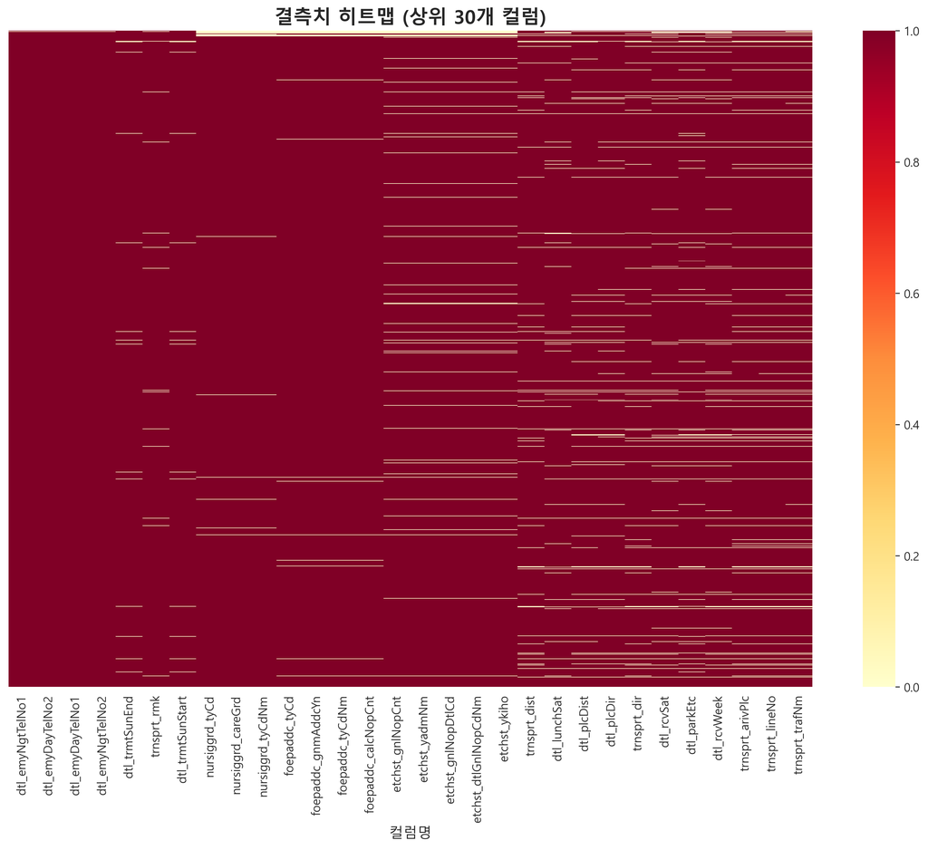

### 주요 결측치 패턴

**응급실 정보 (99.9% 결측)**  
- `dtl_emyDayTelNo1/2`, `dtl_emyNgtTelNo1/2`: 1,152건 결측  
- **해석**: 피부과 의원은 대부분 응급실을 운영하지 않음

**진료시간 정보 (98.8% 결측)**  
- `dtl_trmtSunStart/End`: 1,139건 결측  
- **해석**: 일요일 진료 정보가 대부분 제공되지 않음

**간호등급 정보 (98.7% 결측)**  
- `nursiggrd_tyCd`, `nursiggrd_careGrd`: 1,138건 결측  
- **해석**: 소규모 의원은 간호등급 평가 대상이 아님

> [!NOTE]  
> 높은 결측치 비율은 데이터 품질 문제가 아니라, 피부과 의원의 특성(소규모, 외래 중심)을 반영한 것입니다.

### 원본 데이터 무결성

- ✅ **원본_기관코드**: 결측치 0건 (100% 완전)
- ✅ **원본_병원명**: 결측치 0건 (100% 완전)
- ✅ **원본_주소**: 결측치 0건 (100% 완전)

## 📈 3. 단변량 분석

### 3.1 병원 종별 분포

[figure not shown]

**인사이트**:  
- 강남구 피부과는 대부분 개인 의원 형태로 운영  
- 대형 병원급 피부과는 매우 소수

### 3.2 지역별 분포

[figure not shown]

**주요 발견**:  
- **강남구**: 1,153건 (100.0%)  
- 모든 데이터가 강남구에 집중 (검색 조건에 따른 결과)

### 3.3 설립연도 분포

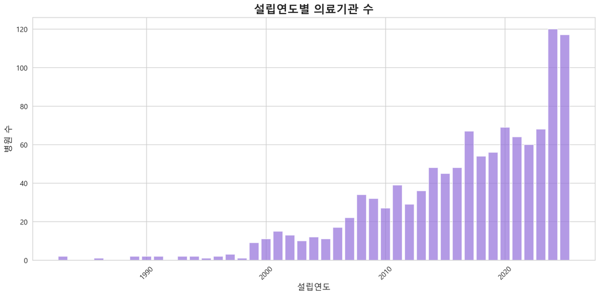

**주요 통계**:  
- **평균 설립연도**: 2017년  
- **중앙값**: 2018년  
- **최소**: 1983년  
- **최대**: 2025년

**인사이트**:  
- 대부분의 피부과가 2010년 이후 개원  
- 최근 5년간(2018-2025) 개원이 집중적으로 증가  
- 강남구 피부과 시장의 활발한 성장세 반영

### 3.4 진료과목 분포

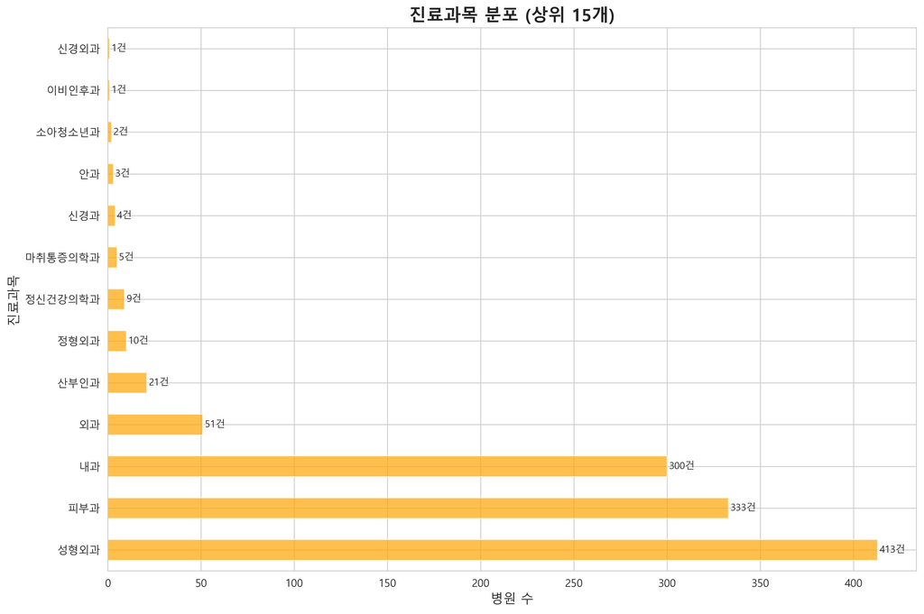

### 3.5 주차 정보 분석

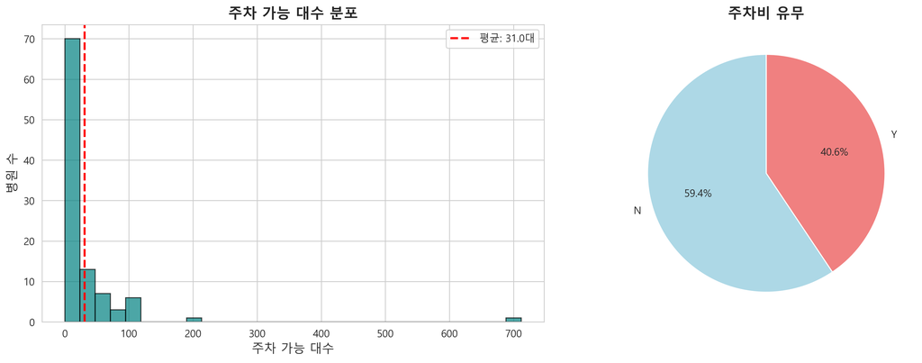

**주차 가능 대수 통계**:  
- **평균**: 31.0대  
- **중앙값**: 10.0대  
- **최소**: 0대  
- **최대**: 712대

**주차비 유무**:  
- **무료(N)**: 60건 (5.2%)  
- **유료(Y)**: 41건 (3.6%)  
- **정보 없음**: 1,052건 (91.2%)

**인사이트**:  
- 대부분의 의원은 주차 정보를 제공하지 않음  
- 주차 정보를 제공하는 의료기관은 평균 31대 수용 가능  
- 중앙값(10대)과 평균(31대)의 차이는 대형 병원의 영향

### 3.6 진료시간 패턴

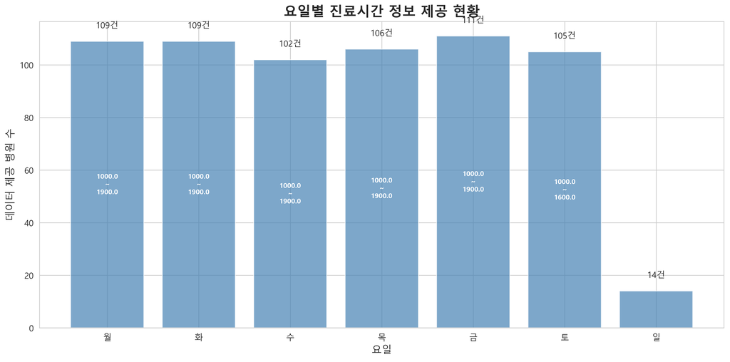

**최빈 진료시간** (정보 제공 병원 기준):  
- **평일**: 10:00 ~ 19:00  
- **토요일**: 10:00 ~ 16:00

**인사이트**:  
- 대부분의 의원(91%)은 진료시간 정보를 API로 제공하지 않음  
- 정보를 제공하는 의원은 평일 9시간, 토요일 6시간 운영  
- 일요일 진료는 거의 없음

## 🎯 4. 주요 인사이트

### 4.1 데이터 품질 인사이트

**✅ 높은 품질의 기본 정보**  
- 진료과목 정보: 100% 완성도  
- 시설 정보: 97.5% 완성도  
- 원본 데이터(기관코드, 병원명, 주소): 100% 완전

**⚠️ 선택적 정보의 낮은 완성도**  
- 세부 정보(진료시간, 주차 등): 6.7%  
- 교통 정보: 4.9%  
- 간호등급 정보: 1.3%

**해석**: API 응답 구조상 필수 정보는 완전하나, 선택적 정보는 의료기관이 직접 입력해야 하므로 완성도가 낮음

### 4.2 비즈니스 인사이트

**1. 강남구 피부과 시장 특성**  
- 99.1%가 개인 의원 형태  
- 최근 5년간 급격한 개원 증가 (2018-2025)  
- 성형외과와의 진료 영역 중복 (미용 시술)

**2. 의료 서비스 패턴**  
- 외래 중심 진료 (응급실 운영 거의 없음)  
- 평일 위주 운영 (일요일 진료 거의 없음)  
- 주차 시설 정보 제공 부족

**3. 데이터 활용 제약**  
- 진료시간, 주차 정보 등 환자 편의 정보 부족  
- 추가 정보는 병원 홈페이지 등 별도 확인 필요

### 4.3 데이터 개선 제안

**단기 개선**  
1. 진료시간 정보 입력 독려 (현재 9% → 목표 50%)  
2. 주차 정보 입력 독려 (현재 9% → 목표 30%)  
3. 교통 정보 입력 독려 (현재 5% → 목표 30%)

**장기 개선**  
1. API 응답 필드 표준화 (선택 필드 → 필수 필드 전환)  
2. 의료기관 정보 입력 인센티브 제공  
3. 정기적인 데이터 품질 모니터링

## 📋 5. 분석 요약

### 주요 발견사항

| 항목 | 발견 내용 |
| --- | --- |
| **데이터 규모** | 1,153건, 93개 컬럼 |
| **의료기관 유형** | 의원 99.1%, 병원급 0.9% |
| **설립 시기** | 평균 2017년, 최근 5년간 집중 개원 |
| **진료과목** | 성형외과 35.8%, 피부과 28.9% |
| **데이터 완성도** | 기본 정보 97%+, 선택 정보 10% 미만 |
| **진료 패턴** | 외래 중심, 평일 위주, 일요일 휴무 |

### 데이터 활용 방안

1. **환자 검색 서비스**: 기본 정보(위치, 종별, 진료과목) 제공 가능
2. **의료기관 분석**: 지역별 의료기관 분포 및 특성 파악
3. **시장 분석**: 개원 트렌드, 진료과목 분포 분석
4. **데이터 보완**: 부족한 정보는 크롤링 또는 별도 수집 필요

## 📁 생성된 시각화 파일

1. 01_missing_data_heatmap.png - 결측치 히트맵
2. 02_hospital_type_distribution.png - 병원 종별 분포
3. 03_district_distribution.png - 시군구별 분포
4. 05_establishment_year_distribution.png - 설립연도 분포
5. 06_department_distribution.png - 진료과목 분포
6. 07_parking_analysis.png - 주차 정보 분석
7. 08_operating_hours_pattern.png - 진료시간 패턴

**분석 완료 시각**: 2026-01-16 01:10:00  
**분석 도구**: Python (pandas, matplotlib, seaborn)  
**분석 스크립트**: eda_analysis.py

생성일시: 2026-01-16 | 분석 도구: Python (pandas, matplotlib, seaborn)

© 2026 의료기관 데이터 분석 프로젝트